# Assignment 5

In this assignment, you'll scrape text from [The California Aggie](https://theaggie.org/) and then analyze the text.

The Aggie is organized by category into article lists. For example, there's a [Campus News](https://theaggie.org/campus/) list, [Arts & Culture](https://theaggie.org/arts/) list, and [Sports](https://theaggie.org/sports/) list. Notice that each list has multiple pages, with a maximum of 15 articles per page.

The goal of exercises 1.1 - 1.3 is to scrape articles from the Aggie for analysis in exercise 1.4.

```python
import pandas as pd
import string
import numpy as np
import requests
import requests_cache
from bs4 import BeautifulSoup
import lxml.html as lx
requests_cache.install_cache('aggiecache')
import nltk
from nltk import corpus
from nltk.stem.porter import PorterStemmer
from sklearn.feature_extraction.text import TfidfVectorizer
from sklearn.neighbors import NearestNeighbors
from matplotlib import pyplot as plt
plt.style.use('ggplot')
%matplotlib inline
from nltk.corpus import stopwords
from collections import Counter
from sklearn.feature_extraction.text import TfidfVectorizer
from wordcloud import WordCloud
```

**Exercise 1.1.** Write a function that extracts all of the links to articles in an Aggie article list. The function should:

- Have a parameter `url` for the URL of the article list.
- Have a parameter `page` for the number of pages to fetch links from. The default should be `1`.
- Return a list of aricle URLs (each URL should be a string).

Test your function on 2-3 different categories to make sure it works.

Hints:

- Be polite to The Aggie and save time by setting up [requests_cache](https://pypi.python.org/pypi/requests-cache) before you write your function.
- Start by getting your function to work for just 1 page. Once that works, have your function call itself to get additional pages.
- You can use [lxml.html](http://lxml.de/lxmlhtml.html) or [BeautifulSoup](https://www.crummy.com/software/BeautifulSoup/bs4/doc/) to scrape HTML. Choose one and use it throughout the entire assignment.

```python
def aggielinkextract(url,page = 1):
    """
    Takes an the article list url and then extracts all the URL links from the page to be used later
    change page in order to increase the amount that it is looking for
    """
    if 'page' not in url and not url.endswith('/'):
        url = url + '/page/'
    elif 'page' not in url:
        url = url+'page/'
    finallist = []
    for x in xrange(page):
        urltemp = url+str(x+1)
        link = requests.get(urltemp)
        linkhtml = link.text
        thehtml = BeautifulSoup(linkhtml,'html.parser')
        content = thehtml.find_all(name='h2',attrs = {'class':'entry-title'})
        for x in xrange(len(content)):
            deeper = content[x]
            name = deeper.find_all('a')[0].attrs['href']
            finallist.append(str(name))
    return finallist
```

```python
#test for URLs
thehtml = BeautifulSoup(requests.get('https://theaggie.org/campus/page/1').text, 'html.parser')
for x in xrange(len(content)):
            deeper = content[x]
            name = deeper.find_all('a')[0].attrs['href']
            print str(name)
```

[output not shown]

```python
test = aggielinkextract('https://theaggie.org/campus/',page = 3)
len(test)
```

```
45
```

```python
test
```

```
['https://theaggie.org/2017/02/20/uc-releases-2016-annual-report-on-sustainable-practices/',
 'https://theaggie.org/2017/02/19/uc-davis-global-affairs-holds-discussion-on-president-donald-trumps-executive-orders-on-immigration/',
 'https://theaggie.org/2017/02/19/trumps-immigration-ban-affects-uc-davis-community/',
 'https://theaggie.org/2017/02/17/uc-davis-students-participate-in-uc-wide-nodapl-day-of-action/',
 'https://theaggie.org/2017/02/17/uc-davis-holds-first-mental-health-conference/',
 'https://theaggie.org/2017/02/16/last-week-in-senate-6/',
 'https://theaggie.org/2017/02/16/2017-asucd-winter-elections-meet-the-candidates/',
 'https://theaggie.org/2017/02/14/shields-library-hosts-new-exhibit-for-davis-centennial/',
 'https://theaggie.org/2017/02/14/student-health-and-counseling-services-hosts-step-up-to-the-plate-campaign/',
 'https://theaggie.org/2017/02/13/pe-classes-may-charge-additional-fees/',
 'https://theaggie.org/2017/02/12/11-new-chancellor-fellows-honored-for-2016/',
 'https://theaggie.org/2017/02/12/muslim-students-respond-to-recent-political-events/',
 'https://theaggie.org/2017/02/12/sexcessful-campaign-launched-in-time-for-valentines-day/',
 'https://theaggie.org/2017/02/10/michael-chan-sworn-in-as-interim-senator/',
 'https://theaggie.org/2017/02/09/university-of-california-regents-meet-approve-first-tuition-raise-in-six-years/',
 'https://theaggie.org/2017/02/16/last-week-in-senate-6/',
 'https://theaggie.org/2017/02/16/2017-asucd-winter-elections-meet-the-candidates/',
 'https://theaggie.org/2017/02/14/shields-library-hosts-new-exhibit-for-davis-centennial/',
 'https://theaggie.org/2017/02/14/student-health-and-counseling-services-hosts-step-up-to-the-plate-campaign/',
 'https://theaggie.org/2017/02/13/pe-classes-may-charge-additional-fees/',
 'https://theaggie.org/2017/02/12/11-new-chancellor-fellows-honored-for-2016/',
 'https://theaggie.org/2017/02/12/muslim-students-respond-to-recent-political-events/',
 'https://theaggie.org/2017/02/12/sexcessful-campaign-launched-in-time-for-valentines-day/',
 'https://theaggie.org/2017/02/10/michael-chan-sworn-in-as-interim-senator/',
 'https://theaggie.org/2017/02/09/university-of-california-regents-meet-approve-first-tuition-raise-in-six-years/',
 'https://theaggie.org/2017/02/09/last-week-in-senate-5/',
 'https://theaggie.org/2017/02/09/uc-davis-receives-2-2-million-from-assembly-bill-2664/',
 'https://theaggie.org/2017/02/06/senator-bill-dodd-visits-uc-davis/',
 'https://theaggie.org/2017/02/05/ab-1887-prevents-use-of-state-funds-including-uc-funds-for-travel-to-states-with-anti-lgbt-laws/',
 'https://theaggie.org/2017/02/02/uc-system-hires-title-ix-coordinator/',
 'https://theaggie.org/2017/02/02/last-week-in-senate-4/',
 'https://theaggie.org/2017/02/02/action-jackson-famous-breeding-donkey-dies-at-29/',
 'https://theaggie.org/2017/02/02/asucd-senator-sam-park-resigns/',
 'https://theaggie.org/2017/01/31/uc-davis-graduate-creates-online-website-to-connect-students-with-professionals-for-career-advice/',
 'https://theaggie.org/2017/01/30/uc-davis-plans-to-bottle-student-wine-for-80/',
 'https://theaggie.org/2017/01/30/uc-davis-to-host-first-ever-mental-health-conference/',
 'https://theaggie.org/2017/01/29/uc-davis-sexual-violence-awareness-and-education-campaign-wins-award/',
 'https://theaggie.org/2017/01/29/uc-davis-study-abroad-secures-22000-in-grants-from-french-government/',
 'https://theaggie.org/2017/01/27/uc-regents-vote-to-raise-tuition-for-uc-campuses/',
 'https://theaggie.org/2017/01/26/former-white-house-speechwriter-comes-to-uc-davis/',
 'https://theaggie.org/2017/01/26/last-week-in-senate-3/',
 'https://theaggie.org/2017/01/26/davis-area-receives-nearly-eight-inches-of-rain-in-first-half-of-january/',
 'https://theaggie.org/2017/01/25/students-walk-out-of-classes-to-protest-trumps-climate-denial/',
 'https://theaggie.org/2017/01/24/uc-davis-ranked-most-sustainable-university-in-the-world/',
 'https://theaggie.org/2017/01/24/us-department-of-transportation-awards-14-million-grant-to-national-center-for-sustainable-transportation/']
```

**Exercise 1.2.** Write a function that extracts the title, text, and author of an Aggie article. The function should:

- Have a parameter `url` for the URL of the article.
- For the author, extract the "Written By" line that appears at the end of most articles. You don't have to extract the author's name from this line.
- Return a dictionary with keys "url", "title", "text", and "author". The values for these should be the article url, title, text, and author, respectively.

For example, for [this article](https://theaggie.org/2017/02/14/project-toto-aims-to-address-questions-regarding-city-finances/) your function should return something similar to this:

```
{
    'author': u'Written By: Bianca Antunez \xa0\u2014\xa0city@theaggie.org',
    'text': u'Davis residents create financial model to make city\'s financial state more transparent To increase transparency between the city\'s financial situation and the community, three residents created a model called Project Toto which aims to improve how the city communicates its finances in an easily accessible design. Jeff Miller and Matt Williams, who are members of Davis\' Finance and Budget Commission, joined together with Davis entrepreneur Bob Fung to create the model plan to bring the project to the Finance and Budget Commission in February, according to Kelly Stachowicz, assistant city manager. "City staff appreciate the efforts that have gone into this, and the interest in trying to look at the city\'s potential financial position over the long term," Stachowicz said in an email interview. "We all have a shared goal to plan for a sound fiscal future with few surprises. We believe the Project Toto effort will mesh well with our other efforts as we build the budget for the next fiscal year and beyond." Project Toto complements the city\'s effort to amplify the transparency of city decisions to community members. The aim is to increase the understanding about the city\'s financial situation and make the information more accessible and easier to understand. The project is mostly a tool for public education, but can also make predictions about potential decisions regarding the city\'s financial future. Once completed, the program will allow residents to manipulate variables to see their eventual consequences, such as tax increases or extensions and proposed developments "This really isn\'t a budget, it is a forecast to see the intervention of these decisions," Williams said in an interview with The Davis Enterprise. "What happens if we extend the sales tax? What does it do given the other numbers that are in?" Project Toto enables users, whether it be a curious Davis resident, a concerned community member or a city leader, with the ability to project city finances with differing variables. The online program consists of the 400-page city budget for the 2016-2017 fiscal year, the previous budget, staff reports and consultant analyses. All of the documents are cited and accessible to the public within Project Toto. "It\'s a model that very easily lends itself to visual representation," Mayor Robb Davis said. "You can see the impacts of decisions the council makes on the fiscal health of the city." Complementary to this program, there is also a more advanced version of the model with more in-depth analyses of the city\'s finances. However, for an easy-to-understand, simplistic overview, Project Toto should be enough to help residents comprehend Davis finances. There is still more to do on the project, but its creators are hard at work trying to finalize it before the 2017-2018 fiscal year budget. "It\'s something I have been very much supportive of," Davis said. "Transparency is not just something that I have been supportive of but something we have stated as a city council objective [ ] this fits very well with our attempt to inform the public of our challenges with our fiscal situation." ',
    'title': 'Project Toto aims to address questions regarding city finances',
    'url': 'https://theaggie.org/2017/02/14/project-toto-aims-to-address-questions-regarding-city-finances/'
}
```

Hints:

- The author line is always the last line of the last paragraph.
- Python 2 displays some Unicode characters as `\uXXXX`. For instance, `\u201c` is a left-facing quotation mark. You can convert most of these to ASCII characters with the method call (on a string)

  ```
  .translate({ 0x2018:0x27, 0x2019:0x27, 0x201C:0x22, 0x201D:0x22, 0x2026:0x20 })
  ```

  If you're curious about these characters, you can look them up on [this page](http://unicode.org/cldr/utility/character.jsp), or read more about [what Unicode is](http://unicode.org/standard/WhatIsUnicode.html).

```python
def aggietextextract(url):
    """
    Takes in a url and returns the name of the article, the text in the article, the author name, and the url
    will return as a dictionary with the entries 'author', 'text', 'title', 'url'
    """
    finaldict = {'url':url, 'author':[],'text':[],'title':[]}
    link = requests.get(url)
    linkhtml = link.text
    thehtml = BeautifulSoup(linkhtml,'html.parser')
    content = thehtml.find_all(name='h1',attrs = {'class':'entry-title'})
    title = str(content[0].text.encode('ascii', 'ignore'))
    finaldict['title'] = title
    content = thehtml.find_all(name='div',attrs = {'itemprop':'articleBody'})[0]
    content = content.find_all(name='p')
    body = ""
    for x in xrange(len(content)-1):
        body = body + content[x].text + ' '
    body = body.translate({ 0x2018:0x27, 0x2019:0x27, 0x201C:0x22, 0x201D:0x22, 0x2026:0x20 })
    author = content[len(content)-1].text
    if not author.startswith('Written'):
        endlist =author.split('\n')
        author = endlist[len(endlist)-1]
        for x in xrange(len(endlist)-1):
            body = body + endlist[x] + ' '
    finaldict['text']=body
    finaldict['author'] = author
    return(finaldict)
```

```python
link = requests.get('https://theaggie.org/2017/02/24/2017-winter-quarter-election-results/')
linkhtml = link.text
thehtml = BeautifulSoup(linkhtml,'html.parser')
thehtml.prettify()
content = thehtml.find_all(name='h1',attrs = {'class':'entry-title'})
print content[0].text
```

```
2017 Winter Quarter election results
```

```python
content = thehtml.find_all(name='div',attrs = {'itemprop':'articleBody'})[0]
content = content.find_all(name='p')
#temp =content[].text
temp.translate({ 0x2018:0x27, 0x2019:0x27, 0x201C:0x22, 0x201D:0x22, 0x2026:0x20 })
content[0].text + ' '+ content[1].text
```

[output not shown]

```python
finances = aggietextextract('https://theaggie.org/2017/02/14/project-toto-aims-to-address-questions-regarding-city-finances/')
finances
```

```
{'author': u'Written By: Bianca Antunez \xa0\u2014\xa0city@theaggie.org',
 'text': u'Davis residents create financial model to make city\'s financial state more transparent To increase transparency between the city\'s financial situation and the community, three residents created a model called Project Toto which aims to improve how the city communicates its finances in a…
 'title': 'Project Toto aims to address questions regarding city finances',
 'url': 'https://theaggie.org/2017/02/14/project-toto-aims-to-address-questions-regarding-city-finances/'}
```

**Exercise 1.3.** Use your functions from exercises 1.1 and 1.2 to get a data frame of 60 [Campus News](https://theaggie.org/campus/) articles and a data frame of 60 [City News](https://theaggie.org/city/) articles. Add a column to each that indicates the category, then combine them into one big data frame.

The "text" column of this data frame will be your corpus for natural language processing in exercise 1.4.

```python
campusurls = aggielinkextract('https://theaggie.org/campus', page=4)
cityurls = aggielinkextract('https://theaggie.org/city/', page = 4)
```

```python
print len(campusurls)
print len(cityurls)
```

```
60
60
```

```python
campusdf = pd.DataFrame()
for x in xrange(len(campusurls)):
    temp = pd.DataFrame(aggietextextract(campusurls[x]),index = [0])
    campusdf =pd.concat([campusdf,temp])
```

```python
campusdf.index = range(60)
campusdf
```

[output not shown]

```python
citydf = pd.DataFrame()
for x in xrange(len(cityurls)):
    temp = pd.DataFrame(aggietextextract(cityurls[x]),index = [0])
    citydf =pd.concat([citydf,temp])
citydf.index = range(60)
```

```python
citydf
```

|  | author | text | title | url |
| --- | --- | --- | --- | --- |
| 0 | Written by: Kaelyn Tuermer-Lee — city@theaggie... | Local Whole Foods closes Feb. 12 After five ye... | Davis Whole Foods Market shuts down | https://theaggie.org/2017/02/23/davis-whole-fo... |
| 1 | Written By: Anya Rehon — city@theaggie.org | Demonstrations take place at hundreds of Plann... | Protest against Planned Parenthood in Woodland... | https://theaggie.org/2017/02/23/protest-agains... |
| 2 | Written By: Bianca Antunez — city@theaggie.org | California Redevelopment Agencies require Davi... | Daviss Historic City Hall building to be put u... | https://theaggie.org/2017/02/23/daviss-histori... |
| 3 | Written by: Caitlyn Sampley — city@theaggie.org | Davis residents show solidarity in wake of tra... | Davis stands with Muslim residents | https://theaggie.org/2017/02/21/davis-stands-w... |
| 4 | Written By: Anya Rehon — city@theaggie.org | CalRecycle donates $197,851 The City of Davis ... | City of Davis awarded funds for new recycling ... | https://theaggie.org/2017/02/20/city-of-davis-... |
| 5 | Written by: Sam Solomon — city@theaggie.org | The world is a weird place Feb. 6 "Chronic pho... | Police Logs | https://theaggie.org/2017/02/19/police-logs-12/ |
| 6 | Written by: Raul Castellanos Jr — city@theaggi... | Mayor Robb Davis reaffirms that the City of Da... | City of Davis to retain sanctuary city status | https://theaggie.org/2017/02/16/city-of-davis-... |
| 7 | Written by: Samantha Solomon — city@theaggie.org | Davis resident Lauren Kirk-Coehlo arrested in ... | Suspect in Davis Islamic Center vandalism arre... | https://theaggie.org/2017/02/15/suspect-in-dav... |
| 8 | Written By: Bianca Antunez — city@theaggie.org | Davis residents create financial model to make... | Project Toto aims to address questions regardi... | https://theaggie.org/2017/02/14/project-toto-a... |
| 9 | Written by: Kaelyn Tuermer-Lee — city@theaggie... | Something smells fishy Jan. 29 "Loud music o... | Police Logs | https://theaggie.org/2017/02/13/police-logs-11/ |
| 10 | Written By: Dianna Rivera — city@theaggie.org | Davis Cemetery District hosts fundraiser with ... | News in Brief: A Valentines Day for everybody | https://theaggie.org/2017/02/12/news-in-brief-... |
| 11 | Written by: Kaelyn Tuermer-Lee — city@theaggie... | Davis Sunrise Rotary Club grant benefits Alzhe... | The musical train to memory lane | https://theaggie.org/2017/02/06/the-musical-tr... |
| 12 | Written by: Kaelyn Tuermer-Lee — city@theaggie... | False alarm, false alarm Jan. 22 "Female was r... | Police Logs | https://theaggie.org/2017/02/05/police-logs-10/ |
| 13 | Written By: Bianca Antunez — city@theaggie.org | Burrowing Owl Preservation Society sues City o... | Davis owls face eviction at Marriott Residence... | https://theaggie.org/2017/02/05/davis-owls-fac... |
| 14 | Written By: Dianna Rivera – city@theaggie.org | The City of Davis hosts festivities in honor o... | Davis Celebrates MLK Day | https://theaggie.org/2017/02/02/davis-celebrat... |
| 15 | Written by: Raul Castellanos Jr — city@theaggi... | Douglas L. Waterman publishes 'It Only Hurts W... | Local author, cyclist rides 2,300 miles | https://theaggie.org/2017/02/02/local-author-c... |
| 16 | Written By: Bianca Antunez— city@theaggie.org | Davis gets a handle on panhandling The Davis C... | City leaders address panhandling issue in Davis | https://theaggie.org/2017/01/31/city-leaders-a... |
| 17 | Written by: Raul Castellanos Jr. — city@theagg... | Local groups meet every week to provide practi... | Toastmasters help members conquer fear of publ... | https://theaggie.org/2017/01/30/toastmasters-h... |
| 18 | Written by: Kaelyn Tuermer-Lee — city@theaggie... | ERIC FREDERICKS [CC BY-SA 2.0] / FLICKRA resur... | Sacramentos new public transportation | https://theaggie.org/2017/01/30/sacramentos-ne... |
| 19 | Written by: Kaelyn Tuermer-Lee — city@theaggie... | The Ukulele Kids Club donates instruments to U... | A symphony to childrens ears | https://theaggie.org/2017/01/29/a-symphony-to-... |
| 20 | Written By: Anya Rehon — city@theaggie.org | Recent report finds that many other California... | Yolo Countys poverty rate higher than before r... | https://theaggie.org/2017/01/29/yolo-countys-p... |
| 21 | Written By: Andie Joldersma — city@theaggie.org | Thriving Pink offers free yoga sessions for ca... | Healing the mind, body and soul | https://theaggie.org/2017/01/26/healing-the-mi... |
| 22 | Written by: Sam Solomon — city@theaggie.org | Slim Jims and beer cans Jan. 15 "Son is making... | Police Logs | https://theaggie.org/2017/01/26/police-logs-9/ |
| 23 | Written By: Anya Rehon — city@theaggie.org | More than 600 women's marches held throughout ... | Thousands gather at Sacramento Capitol buildin... | https://theaggie.org/2017/01/26/thousands-gath... |
| 24 | Written by: Samantha Solomon — city@theaggie.org | Local Masjid had broken windows, slices of bac... | Islamic Center of Davis victim of hate crime | https://theaggie.org/2017/01/25/islamic-center... |
| 25 | Written By: Bianca Antunez — city@theaggie.org | New, modern laundromat spreads love, laundry a... | Love Laundry accommodates student schedules wi... | https://theaggie.org/2017/01/24/love-laundry-a... |
| 26 | Written by: Raul Castellanos Jr. — city@theagg... | Farmer advocacy organization will honor Hering... | Yolo County Farm Bureau to honor Local Winery | https://theaggie.org/2017/01/23/yolo-county-fa... |
| 27 | Written By: Anya Rehon – city@theaggie.org | UC Davis researchers receive funding for salmo... | Chinook salmon spawning in record numbers in P... | https://theaggie.org/2017/01/22/chinook-salmon... |
| 28 | Written by: Andie Joldersma — city@theaggie.org | Grant from Sutter Health supports Davis Pathwa... | Helping the homeless | https://theaggie.org/2017/01/20/helping-the-ho... |
| 29 | Written By: Sam Solomon — city@theaggie.org | From drunkards to eavesdroppers, Davis residen... | Police Logs | https://theaggie.org/2017/01/20/police-logs-8/ |
| 30 | Written by: Raul Castellanos Jr. — city@theagg... | Downtown Davis offers a wide range of Thai cui... | No such thing as too much Thai food | https://theaggie.org/2017/01/17/no-such-thing-... |
| 31 | Written by: Kaelyn Tuermer-Lee – city@theaggie... | Petco Foundation awards $10,000 to local anima... | A dog named Disney wins grant money for Rotts ... | https://theaggie.org/2017/01/16/a-dog-named-di... |
| 32 | Written by: Andie Joldersma — city@theaggie.org | Books by Mail program will deliver materials s... | Yolo County Library materials to be more widel... | https://theaggie.org/2017/01/15/yolo-county-li... |
| 33 | Written by: Sam Solomon — city@theaggie.org | Season's Greetings Edition Dec. 24 "Downstairs... | Police Logs | https://theaggie.org/2017/01/12/police-logs-7/ |
| 34 | Written By: Dianna Rivera — city@theaggie.org | The Davis Manor Neighborhood hosts first Holid... | Neighbors unite | https://theaggie.org/2017/01/12/neighbors-unite/ |
| 35 | Written by: Kaelyn Tuermer-Lee — city@theaggie... | Local author Matt Biers-Ariel's latest novel M... | Sparks fly in Light the Fire | https://theaggie.org/2016/12/09/sparks-fly-in-... |
| 36 | Written by: Raul Castellanos Jr. — city@theagg... | Volunteer program distributes bicycles, aims t... | Bike Campaign offers bicycles to those who can... | https://theaggie.org/2016/12/09/bike-campaign-... |
| 37 | Written By: Juno Bhardwaj-shah — city@theaggie... | Speakers criticize "unconstitutional" system O... | Bail reform advocates gather at annual fundraiser | https://theaggie.org/2016/12/08/bail-reform-ad... |
| 38 | Written by: Samantha Solomon – city@theaggie.org | Live-action retelling of Christmas poem promis... | Twas the Night Before Christmas in Old Sacramento | https://theaggie.org/2016/12/07/twas-the-night... |
| 39 | Written by: Sam Solomon — city@theaggie.org | 35th annual tree lighting ceremony kicks off w... | Childrens Candlelight Parade lights up downtow... | https://theaggie.org/2016/12/05/childrens-cand... |
| 40 | Written by: Sam Solomon – city@theaggie.org | Another week of 'why did people call the polic... | Police Logs | https://theaggie.org/2016/12/04/police-logs-6/ |
| 41 | Written By: Dianna Rivera – city@theaggie.org | The Yolo County Children's Alliance celebrates... | The season of giving | https://theaggie.org/2016/12/04/the-season-of-... |
| 42 | Written by: Samantha Solomon — city@theaggie.org | Students, activists call for solidarity with S... | NoDAPL protest erupts in downtown Davis | https://theaggie.org/2016/12/02/nodapl-protest... |
| 43 | Written by: Andie Joldersma — city@theaggie.org | Participants gathered for 5k, 10k, half marath... | Davis Turkey Trot: more than just another race | https://theaggie.org/2016/12/02/davis-turkey-t... |
| 44 | Written By: Andie Joldersma — city@theaggie.org | Citizens can expect more cost-competitive clea... | Affordable, clean, green energy is coming to Y... | https://theaggie.org/2016/11/30/affordable-cle... |
| 45 | Written by: Bianca Antunez – city@theaggie.org | Davis community renews local parcel tax for K-... | Measure H passes, voters support Davis schools | https://theaggie.org/2016/11/29/measure-h-pass... |
| 46 | Written by: Anya Rehon — city@theaggie.org | College alcohol use, high-risk drinking discus... | Local residents attend Davis town hall meeting | https://theaggie.org/2016/11/29/local-resident... |
| 47 | Written by: Sam Solomon – city@theaggie.org | Looks like it's been an interesting week Nov. ... | Police Logs | https://theaggie.org/2016/11/27/police-logs-5/ |
| 48 | Written by: Raul Castellanos Jr. — city@theagg... | Ornamental piano outside Mishka's Café vandali... | Public piano destroyed in act of vandalism | https://theaggie.org/2016/11/27/public-piano-d... |
| 49 | Written by: Samantha Solomon – city@theaggie.org | Davis residents light candles, promote sanctua... | Holding the Light | https://theaggie.org/2016/11/27/holding-the-li... |
| 50 | Written By: Dianna Rivera — city@theaggie.org | Don't be left in the dark now that Daylight Sa... | Sun down, bike lights out | https://theaggie.org/2016/11/22/sun-down-bike-... |
| 51 | Written By: Sam Solomon — city@theaggie.org | Nov. 7 "Subject stated our pizza is ready and ... | Police Logs | https://theaggie.org/2016/11/22/police-logs-4/ |
| 52 | Written by: Kaelyn Tuermer-Lee – city@theaggie... | Helping the community through Davis Community ... | Tune in to Watermelon Musics strings-for-food ... | https://theaggie.org/2016/11/21/tune-in-to-wat... |
| 53 | Written By: Andie Joldersma — city@theaggie.org | Protesters gather at State Capitol Building fo... | Water is sacred, water is life | https://theaggie.org/2016/11/20/water-is-sacre... |
| 54 | Written By: Anya Rehon — city@theaggie.org | The Yolo County community comes together for h... | The Yolo Food Bank addresses food insecurity | https://theaggie.org/2016/11/17/the-yolo-food-... |
| 55 | Written By: Bianca Antunez — city@theaggie.org | Election results are in; Davis community conce... | Nov. 8 2016: An Election Day many may never fo... | https://theaggie.org/2016/11/17/nov-8-2016-an-... |
| 56 | “Male on a motorized bike pulling a trailer, e... | More turkeys, more tomfoolery, more accidental... | Police Logs | https://theaggie.org/2016/11/15/police-logs-3/ |
| 57 | Written By: Bianca Antunez – city@theaggie.org | Participants line up for Thanksgiving 5k befor... | Yolo Food Banks eighth Annual Running of the T... | https://theaggie.org/2016/11/15/yolo-food-bank... |
| 58 | Written by: Raul Castellanos — city@theaggie.org | Bernie Sanders visits Sacramento to rally for ... | Return of the Bern | https://theaggie.org/2016/11/15/return-of-the-... |
| 59 | Written by: Alana Joldersma –– city@theaggie.org | Indoor facility will provide a cafeteria, clas... | Construction of the All Student Center at Davi... | https://theaggie.org/2016/11/14/construction-o... |

```python
campusdftype = pd.DataFrame(campusurls)
campusdftype['type'] = 'Campus News'

test = pd.concat([campusdf,campusdftype],axis = 1)
del test[0]

citydftype = pd.DataFrame(cityurls)
citydftype['type'] = 'City News'
test1 = pd.concat([citydf,citydftype],axis = 1)
del test1[0]
test1.index = range(60,120)

bigdf = pd.concat([test,test1])
bigdf
```

|  | author | text | title | url | type |
| --- | --- | --- | --- | --- | --- |
| 0 | Written by: Yvonne Leong — campus@theaggie.org | UC Davis leads in sustainability with largest ... | UC releases 2016 Annual Report on Sustainable ... | https://theaggie.org/2017/02/20/uc-releases-20... | Campus News |
| 1 | Written by: Kenton Goldsby — campus@theaggie.org | Speakers, including Interim Chancellor Ralph J... | UC Davis Global Affairs holds discussion on Pr... | https://theaggie.org/2017/02/19/uc-davis-globa... | Campus News |
| 2 | Written by: Kimia Akbari — campus@theaggie.org | Executive order has immediate consequences for... | Trumps immigration ban affects UC Davis community | https://theaggie.org/2017/02/19/trumps-immigra... | Campus News |
| 3 | Written by: Kaitlyn Cheung — campus@theaggie.org | Student protesters march from MU flagpole to M... | UC Davis students participate in UC-wide #NoDA... | https://theaggie.org/2017/02/17/uc-davis-stude... | Campus News |
| 4 | Written by: Jayashri Padmanabhan — campus@thea... | Conference entails full day of speakers, panel... | UC Davis holds first mental health conference | https://theaggie.org/2017/02/17/uc-davis-holds... | Campus News |
| 5 | Written by: Demi Caceres — campus@theaggie.org | Last week in Senate The ASUCD Senate meeting w... | Last week in Senate | https://theaggie.org/2017/02/16/last-week-in-s... | Campus News |
| 6 | Written by: Alyssa Vandenberg and Emilie DeFaz... | Executive: Josh Dalavai and Adilla Jamaludin I... | 2017 ASUCD Winter Elections Meet the Candidates | https://theaggie.org/2017/02/16/2017-asucd-win... | Campus News |
| 7 |  | New showcase provides opportunity for students... | Shields Library hosts new exhibit for Davis ce... | https://theaggie.org/2017/02/14/shields-librar... | Campus News |
| 8 | Written by: Demi Caceres — campus@theaggie.org | Students promote fruit and vegetable meals via... | Student Health and Counseling Services hosts S... | https://theaggie.org/2017/02/14/student-health... | Campus News |
| 9 | Written by: Lindsay Floyd — campus@theaggie.org | New fees to pay for equipment replacement To c... | PE classes may charge additional fees | https://theaggie.org/2017/02/13/pe-classes-may... | Campus News |
| 10 | Written by: Jeanna Totah — campus@theaggie.org | Recipients each rewarded $25,000 for research ... | 11 new Chancellor Fellows honored for 2016 | https://theaggie.org/2017/02/12/11-new-chancel... | Campus News |
| 11 | Written by: Aaron Liss — campus@theaggie.org | Muslim Student Association curates five-part D... | Muslim students respond to recent political ev... | https://theaggie.org/2017/02/12/muslim-student... | Campus News |
| 12 | Written by: Lindsay Floyd — campus@theaggie.or... | Events to promote safe sex On Feb. 1, Student ... | Sexcessful Campaign launched in time for Valen... | https://theaggie.org/2017/02/12/sexcessful-cam... | Campus News |
| 13 | Written by: Alyssa Vandenberg — campus@theagg... | Chan replaces former senator Sam Park Michael ... | Michael Chan sworn in as interim senator | https://theaggie.org/2017/02/10/michael-chan-s... | Campus News |
| 14 | Written by: Kenton Goldsby — campus@theaggie.org | Regents approve tuition increase in 16-4 vote ... | University of California Regents meet, approve... | https://theaggie.org/2017/02/09/university-of-... | Campus News |
| 15 | Written by: Demi Caceres — campus@theaggie.org | Last week in Senate The ASUCD Senate meeting w... | Last week in Senate | https://theaggie.org/2017/02/16/last-week-in-s... | Campus News |
| 16 | Written by: Alyssa Vandenberg and Emilie DeFaz... | Executive: Josh Dalavai and Adilla Jamaludin I... | 2017 ASUCD Winter Elections Meet the Candidates | https://theaggie.org/2017/02/16/2017-asucd-win... | Campus News |
| 17 |  | New showcase provides opportunity for students... | Shields Library hosts new exhibit for Davis ce... | https://theaggie.org/2017/02/14/shields-librar... | Campus News |
| 18 | Written by: Demi Caceres — campus@theaggie.org | Students promote fruit and vegetable meals via... | Student Health and Counseling Services hosts S... | https://theaggie.org/2017/02/14/student-health... | Campus News |
| 19 | Written by: Lindsay Floyd — campus@theaggie.org | New fees to pay for equipment replacement To c... | PE classes may charge additional fees | https://theaggie.org/2017/02/13/pe-classes-may... | Campus News |
| 20 | Written by: Jeanna Totah — campus@theaggie.org | Recipients each rewarded $25,000 for research ... | 11 new Chancellor Fellows honored for 2016 | https://theaggie.org/2017/02/12/11-new-chancel... | Campus News |
| 21 | Written by: Aaron Liss — campus@theaggie.org | Muslim Student Association curates five-part D... | Muslim students respond to recent political ev... | https://theaggie.org/2017/02/12/muslim-student... | Campus News |
| 22 | Written by: Lindsay Floyd — campus@theaggie.or... | Events to promote safe sex On Feb. 1, Student ... | Sexcessful Campaign launched in time for Valen... | https://theaggie.org/2017/02/12/sexcessful-cam... | Campus News |
| 23 | Written by: Alyssa Vandenberg — campus@theagg... | Chan replaces former senator Sam Park Michael ... | Michael Chan sworn in as interim senator | https://theaggie.org/2017/02/10/michael-chan-s... | Campus News |
| 24 | Written by: Kenton Goldsby — campus@theaggie.org | Regents approve tuition increase in 16-4 vote ... | University of California Regents meet, approve... | https://theaggie.org/2017/02/09/university-of-... | Campus News |
| 25 | Written by: Yvonne Leong — campus@theaggie.org | Last week in Senate The ASUCD Senate meeting w... | Last week in Senate | https://theaggie.org/2017/02/09/last-week-in-s... | Campus News |
| 26 | Written by: Jayashri Padmanabhan — campus@thea... | Funding to expand innovation, entrepreneurship... | UC Davis receives $2.2 million from Assembly B... | https://theaggie.org/2017/02/09/uc-davis-recei... | Campus News |
| 27 | Written by: Ivan Valenzuela — campus@theaggie.org | Davis College Democrats host Dodd for question... | Senator Bill Dodd visits UC Davis | https://theaggie.org/2017/02/06/senator-bill-d... | Campus News |
| 28 | Written by: Kenton Goldsby — campus@theaggie.org | Law to affect students selected to attend Nati... | AB 1887 prevents use of state funds, including... | https://theaggie.org/2017/02/05/ab-1887-preven... | Campus News |
| 29 | Written by: Jayashri Padmanabhan — campus@thea... | Kathleen Salvaty to oversee implementation of ... | UC system hires Title IX coordinator | https://theaggie.org/2017/02/02/uc-system-hire... | Campus News |
| ... | ... | ... | ... | ... | ... |
| 90 | Written by: Raul Castellanos Jr. — city@theagg... | Downtown Davis offers a wide range of Thai cui... | No such thing as too much Thai food | https://theaggie.org/2017/01/17/no-such-thing-... | City News |
| 91 | Written by: Kaelyn Tuermer-Lee – city@theaggie... | Petco Foundation awards $10,000 to local anima... | A dog named Disney wins grant money for Rotts ... | https://theaggie.org/2017/01/16/a-dog-named-di... | City News |
| 92 | Written by: Andie Joldersma — city@theaggie.org | Books by Mail program will deliver materials s... | Yolo County Library materials to be more widel... | https://theaggie.org/2017/01/15/yolo-county-li... | City News |
| 93 | Written by: Sam Solomon — city@theaggie.org | Season's Greetings Edition Dec. 24 "Downstairs... | Police Logs | https://theaggie.org/2017/01/12/police-logs-7/ | City News |
| 94 | Written By: Dianna Rivera — city@theaggie.org | The Davis Manor Neighborhood hosts first Holid... | Neighbors unite | https://theaggie.org/2017/01/12/neighbors-unite/ | City News |
| 95 | Written by: Kaelyn Tuermer-Lee — city@theaggie... | Local author Matt Biers-Ariel's latest novel M... | Sparks fly in Light the Fire | https://theaggie.org/2016/12/09/sparks-fly-in-... | City News |
| 96 | Written by: Raul Castellanos Jr. — city@theagg... | Volunteer program distributes bicycles, aims t... | Bike Campaign offers bicycles to those who can... | https://theaggie.org/2016/12/09/bike-campaign-... | City News |
| 97 | Written By: Juno Bhardwaj-shah — city@theaggie... | Speakers criticize "unconstitutional" system O... | Bail reform advocates gather at annual fundraiser | https://theaggie.org/2016/12/08/bail-reform-ad... | City News |
| 98 | Written by: Samantha Solomon – city@theaggie.org | Live-action retelling of Christmas poem promis... | Twas the Night Before Christmas in Old Sacramento | https://theaggie.org/2016/12/07/twas-the-night... | City News |
| 99 | Written by: Sam Solomon — city@theaggie.org | 35th annual tree lighting ceremony kicks off w... | Childrens Candlelight Parade lights up downtow... | https://theaggie.org/2016/12/05/childrens-cand... | City News |
| 100 | Written by: Sam Solomon – city@theaggie.org | Another week of 'why did people call the polic... | Police Logs | https://theaggie.org/2016/12/04/police-logs-6/ | City News |
| 101 | Written By: Dianna Rivera – city@theaggie.org | The Yolo County Children's Alliance celebrates... | The season of giving | https://theaggie.org/2016/12/04/the-season-of-... | City News |
| 102 | Written by: Samantha Solomon — city@theaggie.org | Students, activists call for solidarity with S... | NoDAPL protest erupts in downtown Davis | https://theaggie.org/2016/12/02/nodapl-protest... | City News |
| 103 | Written by: Andie Joldersma — city@theaggie.org | Participants gathered for 5k, 10k, half marath... | Davis Turkey Trot: more than just another race | https://theaggie.org/2016/12/02/davis-turkey-t... | City News |
| 104 | Written By: Andie Joldersma — city@theaggie.org | Citizens can expect more cost-competitive clea... | Affordable, clean, green energy is coming to Y... | https://theaggie.org/2016/11/30/affordable-cle... | City News |
| 105 | Written by: Bianca Antunez – city@theaggie.org | Davis community renews local parcel tax for K-... | Measure H passes, voters support Davis schools | https://theaggie.org/2016/11/29/measure-h-pass... | City News |
| 106 | Written by: Anya Rehon — city@theaggie.org | College alcohol use, high-risk drinking discus... | Local residents attend Davis town hall meeting | https://theaggie.org/2016/11/29/local-resident... | City News |
| 107 | Written by: Sam Solomon – city@theaggie.org | Looks like it's been an interesting week Nov. ... | Police Logs | https://theaggie.org/2016/11/27/police-logs-5/ | City News |
| 108 | Written by: Raul Castellanos Jr. — city@theagg... | Ornamental piano outside Mishka's Café vandali... | Public piano destroyed in act of vandalism | https://theaggie.org/2016/11/27/public-piano-d... | City News |
| 109 | Written by: Samantha Solomon – city@theaggie.org | Davis residents light candles, promote sanctua... | Holding the Light | https://theaggie.org/2016/11/27/holding-the-li... | City News |
| 110 | Written By: Dianna Rivera — city@theaggie.org | Don't be left in the dark now that Daylight Sa... | Sun down, bike lights out | https://theaggie.org/2016/11/22/sun-down-bike-... | City News |
| 111 | Written By: Sam Solomon — city@theaggie.org | Nov. 7 "Subject stated our pizza is ready and ... | Police Logs | https://theaggie.org/2016/11/22/police-logs-4/ | City News |
| 112 | Written by: Kaelyn Tuermer-Lee – city@theaggie... | Helping the community through Davis Community ... | Tune in to Watermelon Musics strings-for-food ... | https://theaggie.org/2016/11/21/tune-in-to-wat... | City News |
| 113 | Written By: Andie Joldersma — city@theaggie.org | Protesters gather at State Capitol Building fo... | Water is sacred, water is life | https://theaggie.org/2016/11/20/water-is-sacre... | City News |
| 114 | Written By: Anya Rehon — city@theaggie.org | The Yolo County community comes together for h... | The Yolo Food Bank addresses food insecurity | https://theaggie.org/2016/11/17/the-yolo-food-... | City News |
| 115 | Written By: Bianca Antunez — city@theaggie.org | Election results are in; Davis community conce... | Nov. 8 2016: An Election Day many may never fo... | https://theaggie.org/2016/11/17/nov-8-2016-an-... | City News |
| 116 | “Male on a motorized bike pulling a trailer, e... | More turkeys, more tomfoolery, more accidental... | Police Logs | https://theaggie.org/2016/11/15/police-logs-3/ | City News |
| 117 | Written By: Bianca Antunez – city@theaggie.org | Participants line up for Thanksgiving 5k befor... | Yolo Food Banks eighth Annual Running of the T... | https://theaggie.org/2016/11/15/yolo-food-bank... | City News |
| 118 | Written by: Raul Castellanos — city@theaggie.org | Bernie Sanders visits Sacramento to rally for ... | Return of the Bern | https://theaggie.org/2016/11/15/return-of-the-... | City News |
| 119 | Written by: Alana Joldersma –– city@theaggie.org | Indoor facility will provide a cafeteria, clas... | Construction of the All Student Center at Davi... | https://theaggie.org/2016/11/14/construction-o... | City News |

120 rows × 5 columns

**Exercise 1.4.** Use the Aggie corpus to answer the following questions. Use plots to support your analysis.

- What topics does the Aggie cover the most? Do city articles typically cover different topics than campus articles?
- What are the titles of the top 3 pairs of most similar articles? Examine each pair of articles. What words do they have in common?
- Do you think this corpus is representative of the Aggie? Why or why not? What kinds of inference can this corpus support? Explain your reasoning.

Hints:

- The [nltk book](http://www.nltk.org/book/) and [scikit-learn documentation](http://scikit-learn.org/stable/modules/feature_extraction.html#text-feature-extraction) may be helpful here.
- You can determine whether city articles are "near" campus articles from the similarity matrix or with k-nearest neighbors.
- If you want, you can use the [wordcloud](http://amueller.github.io/word_cloud/) package to plot a word cloud. To install the package, run

  ```
  conda install -c https://conda.anaconda.org/amueller wordcloud
  ```

  in a terminal. Word clouds look nice and are easy to read, but are less precise than bar plots.

```python
reuters = [nltk.corpus.reuters.raw(i) for i in nltk.corpus.reuters.fileids()]

stemmer = PorterStemmer().stem
print stemmer("commercially"), stemmer("commercial")

tokenize = nltk.word_tokenize

def stem(tokens,stemmer = PorterStemmer().stem):
    return [stemmer(w.lower()) for w in tokens]

def lemmatize(text):
    """
    Extract simple lemmas based on tokenization and stemming
    Input: string
    Output: list of strings (lemmata)
    """
    return stem(tokenize(text))
vectorizer = TfidfVectorizer(tokenizer=lemmatize,stop_words="english",smooth_idf=True,norm=None)
```

```
commerci commerci
```

```python
campuswords = []
for x in xrange(60):
    temp = nltk.word_tokenize(bigdf['text'][x])
    campuswords = campuswords +temp

citywords = []
for x in xrange(60,120):
    temp = nltk.word_tokenize(bigdf['text'][x])
    citywords = citywords +temp
filtered_campus = [word for word in campuswords if word not in stopwords.words('english')]
filtered_city = [word for word in citywords if word not in stopwords.words('english')]
allwords = filtered_campus + filtered_city
```

```python
tfs = vectorizer.fit_transform(allwords)
```

```python
sim = tfs.dot(tfs.T)
```

```python
sim.mean()
```

```
0.18493294548887143
```

```python
z = 0
for x in xrange(60):
    for y in xrange(60):
        if campusdf['title'][x] == citydf['title'][y]:
            z = z +1
z
```

```
0
```

```python
filtered_campus = [''.join(c for c in s if c not in string.punctuation) for s in filtered_campus]
filtered_campus = [s for s in filtered_campus if s]
thing = Counter(filtered_campus)
foo = pd.DataFrame.from_dict(thing, orient='index').reset_index()
foo = foo.sort([0],ascending = False)
foo
```

|  | index | 0 |
| --- | --- | --- |
| 4969 | UC | 352 |
| 728 | said | 330 |
| 3641 | Davis | 300 |
| 3159 | The | 263 |
| 2069 | s | 261 |
| 2524 | students | 258 |
| 2206 | I | 244 |
| 4777 | student | 146 |
| 5074 | campus | 146 |
| 3129 | also | 110 |
| 1045 | people | 92 |
| 3030 | major | 84 |
| 1946 | We | 80 |
| 247 | ASUCD | 78 |
| 3354 | community | 76 |
| 1239 | nt | 73 |
| 2962 | event | 68 |
| 185 | would | 66 |
| 2973 | health | 63 |
| 4871 | like | 60 |
| 4369 | really | 60 |
| 3381 | California | 59 |
| 1690 | year | 58 |
| 2234 | It | 57 |
| 384 | one | 57 |
| 1758 | think | 55 |
| 4269 | sexual | 55 |
| 233 | work | 54 |
| 164 | campaign | 54 |
| 109 | new | 54 |
| ... | ... | ... |
| 3239 | merchandise | 1 |
| 3241 | Protests | 1 |
| 1009 | zeroemission | 1 |
| 3244 | consensual | 1 |
| 3245 | Neighborhoods | 1 |
| 3249 | mistakes | 1 |
| 3250 | spiked | 1 |
| 3252 | diabetes | 1 |
| 988 | hay | 1 |
| 3255 | Aliki | 1 |
| 996 | occurring | 1 |
| 3228 | Oakville | 1 |
| 3227 | sunny | 1 |
| 997 | hat | 1 |
| 3206 | nervous | 1 |
| 1007 | posed | 1 |
| 1006 | Half | 1 |
| 1005 | warranted | 1 |
| 3212 | conducted | 1 |
| 1003 | alerting | 1 |
| 3216 | knowledgeable | 1 |
| 3217 | 8 | 1 |
| 3219 | 68 | 1 |
| 3220 | Michelle | 1 |
| 3221 | Defense | 1 |
| 1002 | deputy | 1 |
| 1000 | Tri | 1 |
| 3224 | compiled | 1 |
| 998 | stopping | 1 |
| 5139 | disruptive | 1 |

5140 rows × 2 columns

```python
filtered_city = [''.join(c for c in s if c not in string.punctuation) for s in filtered_city]
filtered_city = [s for s in filtered_city if s]
thing = Counter(filtered_city)
foo1 = pd.DataFrame.from_dict(thing, orient='index').reset_index()
foo1 =foo1.sort([0],ascending = False)
foo1
```

|  | index | 0 |
| --- | --- | --- |
| 3905 | Davis | 336 |
| 2209 | s | 266 |
| 771 | said | 209 |
| 3379 | The | 207 |
| 2357 | I | 102 |
| 1100 | people | 100 |
| 3587 | community | 95 |
| 3331 | It | 79 |
| 1895 | city | 77 |
| 2072 | Sacramento | 68 |
| 2068 | We | 66 |
| 2705 | students | 61 |
| 4250 | Yolo | 60 |
| 1800 | year | 57 |
| 3116 | food | 56 |
| 1882 | one | 56 |
| 1260 | County | 56 |
| 3351 | also | 55 |
| 3176 | event | 51 |
| 4556 | This | 51 |
| 3674 | City | 49 |
| 4780 | local | 46 |
| 4260 | residents | 45 |
| 4854 | state | 45 |
| 2852 | public | 45 |
| 2389 | In | 45 |
| 5128 | like | 44 |
| 192 | would | 44 |
| 1214 | support | 43 |
| 1310 | nt | 41 |
| ... | ... | ... |
| 1418 | minute | 1 |
| 1417 | Where | 1 |
| 1415 | emphasized | 1 |
| 1411 | Laurie | 1 |
| 1409 | delves | 1 |
| 3337 | males | 1 |
| 1426 | standards | 1 |
| 1428 | item | 1 |
| 1429 | 55 | 1 |
| 3311 | jurisdiction | 1 |
| 3286 | relationship | 1 |
| 1442 | findings | 1 |
| 3289 | park | 1 |
| 1440 | talked | 1 |
| 3291 | problemsolving | 1 |
| 3294 | Nearly | 1 |
| 3295 | boredom | 1 |
| 1437 | oneonone | 1 |
| 3297 | 5100 | 1 |
| 3299 | Road | 1 |
| 1434 | Celebration | 1 |
| 3301 | Gown | 1 |
| 3303 | grew | 1 |
| 3304 | critically | 1 |
| 3305 | aren’t | 1 |
| 3307 | double | 1 |
| 3308 | instruction | 1 |
| 3309 | grey | 1 |
| 1431 | recall | 1 |
| 3787 | workers | 1 |

5389 rows × 2 columns

```python
cloud
```

[output not shown]

[output cut: 49 more lines]

```
(-0.5, 399.5, 199.5, -0.5)
```

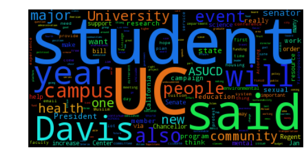

```python
allcampus = ''
for x in xrange(len(campusdf)):
    allcampus = allcampus + campusdf['text'][x]
wordcloud = WordCloud().generate(allcampus)
plt.imshow(wordcloud)
plt.axis('off')
```

```
(-0.5, 399.5, 199.5, -0.5)
```

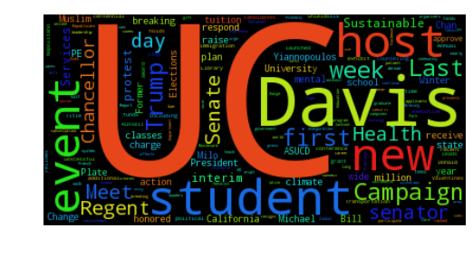

```python
allcampustitle = ''
for x in xrange(len(campusdf)):
    allcampustitle = allcampustitle + ' ' + campusdf['title'][x]
wordcloud = WordCloud().generate(allcampustitle)
plt.imshow(wordcloud)
plt.axis('off')
```

```
(-0.5, 399.5, 199.5, -0.5)
```

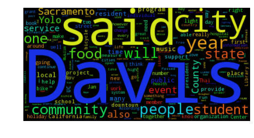

```python
allcity = ''
for x in xrange(len(citydf)):
    allcity = allcity + citydf['text'][x]
wordcloud = WordCloud().generate(allcity)
plt.imshow(wordcloud)
plt.axis('off')
```

```
(-0.5, 399.5, 199.5, -0.5)
```

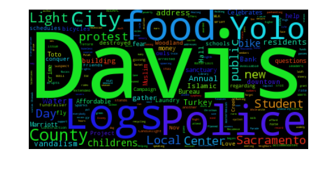

```python
allcitytitle = ''
for x in xrange(len(citydf)):
    allcitytitle = allcitytitle + " " + citydf['title'][x]
wordcloud = WordCloud().generate(allcitytitle)
plt.imshow(wordcloud)
plt.axis('off')
```

# City Articles and Campus Articles

We also see in the titles that UC is more important than Davis in the campus vs the city news with the city news more focused on police, food, and the Yolo county as a whole.

In the bodies, we see again that UC is more important than Davis overall and that for the campus, Student is one of the major words overall while for the city, city is much larger. Community is very similar though which is good to see that being cared about for both the city and Campus news that there is a connection between the campus and the city and a care for the community. They both though seem to have similar diversity in words though with no big similarity in that department.

# Representation of the Aggie

I do not think this is representative of the Aggie since this is just the 60 most recent articles, a better representation would take random articles from across the site, not just the campus and city news sections and randomly across time. This dataset only predicts those that are recent articles in regards to campus and city news unfortunately